# finalproject

2023-12-04

```r
library(tidyverse)
```

```r
library(ggplot2)
library(cowplot)
```

```r
# CSV CONVERSION

# this is a function to convert .txt files into .csv files in a particular directory
# to convert a whole directory, simply write "csv_conversion('dir')", in which dir is the directory you want to transform the files in
csv_conversion <- function(dir) {
  # create a file to get all the files together from a directory
  files <- list.files(dir,"\\.txt",full.names=TRUE)
  # if/else statment to avoid converting files already in csv format
  if (length(files)==0) {
    print("The files in this directory are already in .csv format.")
  } else{
    for (i in 1:length(files)){
      # for loop through each .txt file to identify it and read it
      new_csv_name <- sub("\\.txt", ".csv", files[i])
      data <- read.table(files[i], header = TRUE, sep = "")
      # then, write a .csv file given the .txt file and remove the old .txt file
      write.csv(data, new_csv_name, row.names = FALSE)
      file.remove(files[i])
    }
    print("All files in this directory have been converted to .csv.")
  }
}

csv_conversion('countryY')
```

```
## [1] "The files in this directory are already in .csv format."
```

```r
# COMPILE FUNCTION

# this is already assuming that the files are in CSV format
# this is a function that will compile all the csv files in TWO directories into 1 csv file
# to compile a whole directory, simply write "csv_compile('dir', 'dir2' )", in which dir is the directory you want to compile all the files
csv_compile <- function(dir1, dir2) {
  #create a data frame to store all the csv file data
  compile_all <- data.frame(matrix(ncol=14, nrow=0))
  # create a file to get all the files together from a directory (in csv format)
  files_csv <- list.files(dir1,"\\.csv$",full.names = TRUE)
  files_csv2 <- list.files(dir2,"\\.csv$",full.names = TRUE)
  output_file <- paste("allFiles.csv")
  cat("You have three options:\n",
      "1. Remove rows with NA in any of the columns.\n",
      "2. Include NAs in the compiled data but be warned of their presence.\n",
      "3. Include NAs in the compiled data without a warning.\n",
      "Please choose 1, 2, or 3.\n")
  answer<-readline("Answer: ")
  for(i in 1:length(files_csv)){
    current_file<-read.csv(files_csv[i]) # get path of current file
    file_name<-basename(files_csv[i])  #extract the country name
    day<-(strsplit(file_name,"[_.]")[[1]][2])# extract the day from each csv file name using strsplit
    if (basename(dir1) == "countryX"){ #switching country to X or Y
      country<- 'X'}
     else if (basename(dir2) == 'countryY') {
      country<- 'Y'
    }
    current_file<-cbind(current_file,country,day) # column bind the data in the current file and the country and the day
    compile_all<-rbind(compile_all,current_file)  # row bind all the new data in the current file and the compile_all
  }
  if(sum(is.na(compile_all)) > 0) {
    if(answer=="1"){
      compile_all <- na.omit(compile_all)
    } else if(answer=="2") {
      print("Warning! There are NAs present in the compiled data")
    }
  }
#for second file input
for(i in 1:length(files_csv2)){
    current_file<-read.csv(files_csv2[i])  # get path of current file
    file_name<-basename(files_csv2[i])  #extract the country name
    day<-(strsplit(file_name,"[_.]")[[1]][2])
     if (basename(dir2) == "countryX"){ #switching country to X or Y
      country<- 'X'}
    else if (basename(dir2) == 'countryY') {
      country<- 'Y'
    }
    current_file<-cbind(current_file,country,day) # column bind the data in the current file and the country and the day
    compile_all<-rbind(compile_all,current_file) # row bind all the new data in the current file and the compile_all
}
   # remove the NA if the user chooses answer 1 and provide a warning but don't remove NA if the user choose answer 2
  if(sum(is.na(compile_all)) > 0) {
    if(answer=="1"){
      compile_all <- na.omit(compile_all)
    } else if(answer=="2") {
      print("Warning! There are NAs present in the compiled data")
    }
  }
  # return the compiled csv file, called compile_all.
  return(write.csv(compile_all, file=output_file, row.names = FALSE))
}

csv_compile('countryX', 'countryY')
```

```
## You have three options:
##  1. Remove rows with NA in any of the columns.
##  2. Include NAs in the compiled data but be warned of their presence.
##  3. Include NAs in the compiled data without a warning.
##  Please choose 1, 2, or 3.
## Answer:
```

```
## [1] "Summarization of Total Counts:"
## [1] "The total amount of infected patients in X: 15630"
## [1] "The total amount of infected patients in Y: 6848"
## [1] "The total amount of screens are: 39744"
## [1] "Distribution of Infected Patients"
## [1] "The percent of patients that were infected: 56.5569645732689"
## [1] "The percent of infected patients that identify as male: 28.3288043478261"
## [1] "The percent of patients that identify as male: 50.1534822866345"
## [1] "The percent of infected patients that identify as female: 28.2281602254428"
## [1] "The percent of patients that identify as female: 49.8465177133655"
```

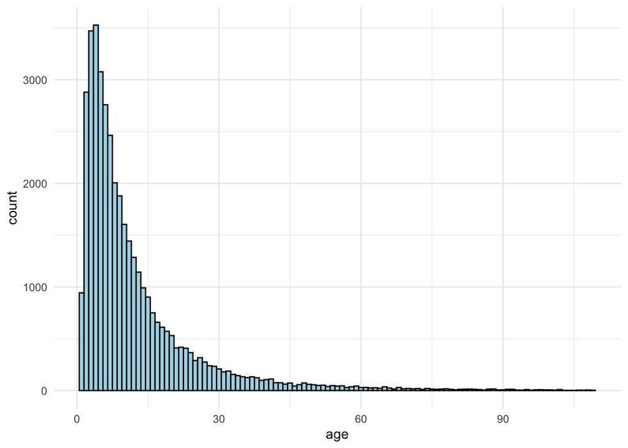

```r
#Summarizing the Compiled Data Set


#Function takes in filename argument with parentheses, for example: 'allFiles.csv'
countingCases <- function(filename){

data <- read.csv(filename, header = TRUE, sep = ',') #reads the passed in csv file and gives variable name data
  xcount<- 0
  ycount <- 0
  malecount<-0
  femalecount<- 0

#counting infected patients
  for (line in 1:nrow(data)){ #groups infected patients by X
    if (data$country[line] == 'X'){
    for (x in 3:12){ #column 3-12 are the markers so counting between these rows to see if there is a 1
      if (data[line,x] == 1){ #patient only infected with marker if there is a 1
        xcount <- xcount + 1 #counting
        break;
      }
    }
    }
    else if (data$country[line] == 'Y'){ #groups infected patients by Y doing previous step
    for (x in 3:12){
      if (data[line,x] == 1){
       ycount <- ycount + 1
       break;}
    }
    }
  }

print("Summarization of Total Counts:")

  print(paste('The total amount of infected patients in X:', xcount))
  print(paste('The total amount of infected patients in Y:', ycount))

#total amount of screens

totalscreens<- 0
  for (line in 1:nrow(data)){ #counts the total screen by iterating through each row (person)
      totalscreens = totalscreens +1  }

totalinfected <- ((xcount + ycount)/totalscreens) *100 # total infected calculated by total infected /total screens

  print(paste('The total amount of screens are:', totalscreens))


# finding male and female patient percentages

totalmalepatients<-nrow(data[data$gender == 'male',]) #counting total male patients by rows with gender == male
totalfemalepatients<- nrow(data[data$gender == 'female',]) #same as above but for female

  for (line in 1:nrow(data)){
     for (x in 3:12){ #iterates only through the markers and passes following conditions
    if (data$gender[line] == 'male' & data[line,x] == 1){ #iterating through to find which males are infected
        malecount <- malecount + 1 #counts infected males
        break;}
    else if (data$gender[line] == 'female' & data[line,x] == 1){ #iterates through females that are infected
        femalecount <- femalecount + 1 #counts infected females
        break;}
     }
  }


totalmale <- totalmalepatients/totalscreens*100 #percentage of males infected out of all screens
maleratio <- malecount/totalscreens *100 #percentage of males out of all screens
totalfemale<- totalfemalepatients/totalscreens*100 #percentage of females infected out of all screens
femaleratio<- femalecount/totalscreens *100 #perecentage of females out of all screens
print('Distribution of Infected Patients')
print(paste('The percent of patients that were infected:', totalinfected))
print(paste('The percent of infected patients that identify as male:', maleratio))
print(paste('The percent of patients that identify as male:', totalmale))
print(paste('The percent of infected patients that identify as female:', femaleratio))
print(paste('The percent of patients that identify as female:', totalfemale))

#Age distribution table
ggplot (data = data, aes(x = age)) +
  geom_histogram(binwidth = 1, fill ="lightblue", color = "black") +
  theme_minimal()
}



countingCases('allFiles.csv') #passing in the previous file made from function 2
```

Question 1: In which country (X or Y) did the disease outbreak likely begin?

Based on the summary found above, it is likely that the disease outbreak began in country X. Country X had over double the amount of infected patients than country Y, suggesting that the disease originated from country X and was able to spread very quickly before reaching country Y. The disease itself seems impartial to gender, and effects relatively the same percentage of females as it does males.

```r
# Import the data

data <- read.csv('allFiles.csv', header = TRUE, sep = ",")
data_country_x <- data[data$country == "X", ]
data_country_y <- data[data$country == "Y", ]

# Counting Individual Markers by iterating through each row
marker_counts_x <- integer(10)
marker_counts_y <- integer(10)

for (marker_index in 1:10) {
  marker_col <- marker_index + 2  # Aligning with the actual column in the dataset, as we are starting two over in the data set =, column 3
  for (row in 1:nrow(data_country_x)) {
    if (data_country_x[row, marker_col] == 1) {
      marker_counts_x[marker_index] <- marker_counts_x[marker_index] + 1
    }
  }

  for (row in 1:nrow(data_country_y)) {
    if (data_country_y[row, marker_col] == 1) {
      marker_counts_y[marker_index] <- marker_counts_y[marker_index] + 1
    }
  }
}

#Display the counts for each country
print("Marker counts for country X:")
```

```
## [1] "Marker counts for country X:"
```

```r
for (i in 1:length(marker_counts_x)) {
  print(paste("Marker", i,"total is", marker_counts_x[i]))
}
```

```
## [1] "Marker 1 total is 6545"
## [1] "Marker 2 total is 6658"
## [1] "Marker 3 total is 6549"
## [1] "Marker 4 total is 6765"
## [1] "Marker 5 total is 6605"
## [1] "Marker 6 total is 55"
## [1] "Marker 7 total is 78"
## [1] "Marker 8 total is 78"
## [1] "Marker 9 total is 66"
## [1] "Marker 10 total is 63"
```

```r
print("Marker counts for country Y:")
```

```
## [1] "Marker counts for country Y:"
```

```r
for (i in 1:length(marker_counts_y)) {
  print(paste("Marker", i,"total is", marker_counts_y[i]))
}
```

```
## [1] "Marker 1 total is 198"
## [1] "Marker 2 total is 205"
## [1] "Marker 3 total is 210"
## [1] "Marker 4 total is 809"
## [1] "Marker 5 total is 791"
## [1] "Marker 6 total is 1879"
## [1] "Marker 7 total is 1905"
## [1] "Marker 8 total is 1425"
## [1] "Marker 9 total is 1467"
## [1] "Marker 10 total is 1439"
```

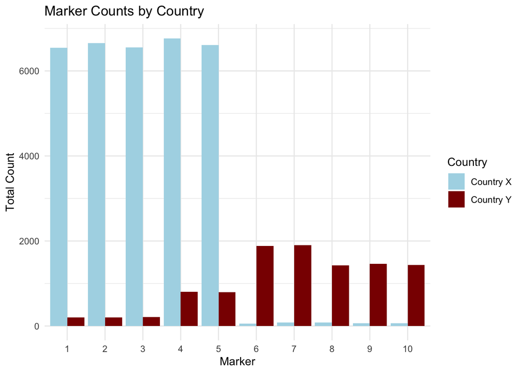

```r
# Create a data frame from the marker_counts_x and marker_counts_y vectors
marker_data <- data.frame(
  Marker = rep(1:10, times = 2), #Create a repeating sequence for marker number
  Country = factor(rep(c("Country X", "Country Y"), each = 10)), #created variable factors that repeats "Country X" 10 times than Country Y for the next 10
  Count = c(marker_counts_x, marker_counts_y) #Puts the two marker_counts(x and y) into one vector
)

# Use ggplot2 to create the bar plot
ggplot(marker_data, aes(x = factor(Marker), y = Count, fill = Country)) +
  geom_bar(stat = "identity", position = position_dodge()) + #Position_dodge places Country X and Y bars next to each
  scale_fill_manual(values = c("lightblue", "darkred")) + #Filling the country bars in light blue and dark red
  labs(title = "Marker Counts by Country",
       x = "Marker",
       y = "Total Count") +
  theme_minimal()
```

Question 2: If country Y develops a vaccine for the disease, is it likely to work for citizens of country x?

It is likely that if country Y develops a vaccine for the disease, it is less likely for the vaccine to work on country X. This is because most of the markers with a high amount of infected patients in country Y, have a low amount of infected patients in country X. For example, country Y would likely make a vaccine that deals with markers 6,7,8,9,and 10 because there are higher counts of infected patients found in these markers. This is not the case for country X, which has its lowest amounts of infected patients in markers 6,7,8,9, and 10. Instead, country X has its highest counts of infected patients in markers 1,2,3,4,and 5 which is where country Y has their least infected amount of patients.